# Session 3: Working with Files

ESS: Introduction to Web Scraping and Data Management for Social Scientists

Johannes B. Gruber

2026-07-22

# Introduction

## This Course

| Day | Session |
| --- | --- |
| 1 | Introduction |
| 2 | Data Structures and Wrangling |
| 3 | Working with Files |
| 4 | Linking and joining data & SQL |
| 5 | Scaling, Reporting and Database Software |
| 6 | Introduction to the Web |
| 7 | Static Web Pages |
| 8 | Application Programming Interface (APIs) |
| 9 | Interactive Web Pages |
| 10 | Building a Reproducible Research Project |

## The Plan for Today

In this session, you learn:

- how to use files efficiently and how to solve problems using files
- good practices for transparent and efficient file usage
- how to work with many files at the same time
- and how you can facilitate collaborative working with files

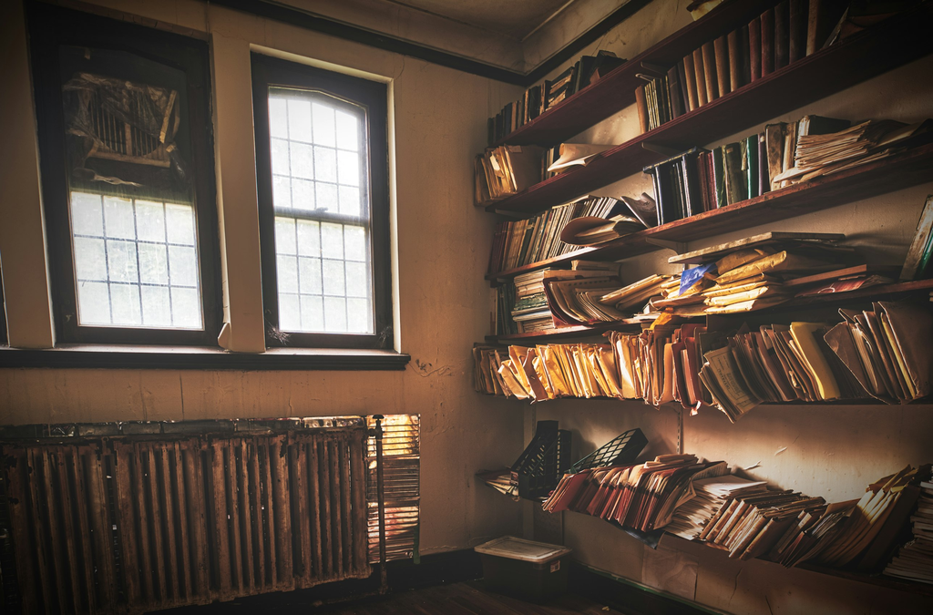

[JF Martin](https://unsplash.com/@numericcitizen) via unsplash.com

# Files

## What are files

- during analysis, your data resides in memory
- when the R is closed, the memory is emptied
- data then needs to be stored in a file (or files) on your disk/network/cloud (or a database)
- there are many different file types, some better suited for data storage than others (e.g., JPEG vs. XLSX)

## Let’s get some files

```r
if (!dir.exists("data/files")) {
  dir.create("data", showWarnings = FALSE)
  # download the zip file containing the data from Weidmann (2023)
  if (!file.exists("data/main.zip")) {
    curl::curl_download(
      url = "https://github.com/nilsbw/dmbook-setup/archive/refs/heads/main.zip",
      destfile = "data/main.zip"
    )
  }
  # extract the archive
  unzip("data/main.zip", exdir = "data")
  # we are only interested in the files for chapter 4, so we move them up
  file.rename("data/dmbook-setup-main/ch04", "data/files")
  # now we can clean up
  unlink("data/dmbook-setup-main", recursive = TRUE)
}
```

Now let’s have a look:

```r
list.files("data/files")
```

```
 [1] "csv-example-quotes.csv"    "csv-example-semicolon.csv"
 [3] "csv-example.csv"           "journalism.sav"
 [5] "leaders-twitter.Rdata"     "REFERENCES.md"
 [7] "terrorism-targets.dta"     "un-secretaries-ascii.txt"
 [9] "un-secretaries.txt"        "unsc-membership.xls"
```

## Operating system shenanigans

Windows and macOS annoyingly hide file extensions. I generally recommend you change that:

### Windows

[figure not shown]

### macOS

[figure not shown]

## Plain text vs. binary files

Basic difference between file types:

- some contain information stored as *plain text*

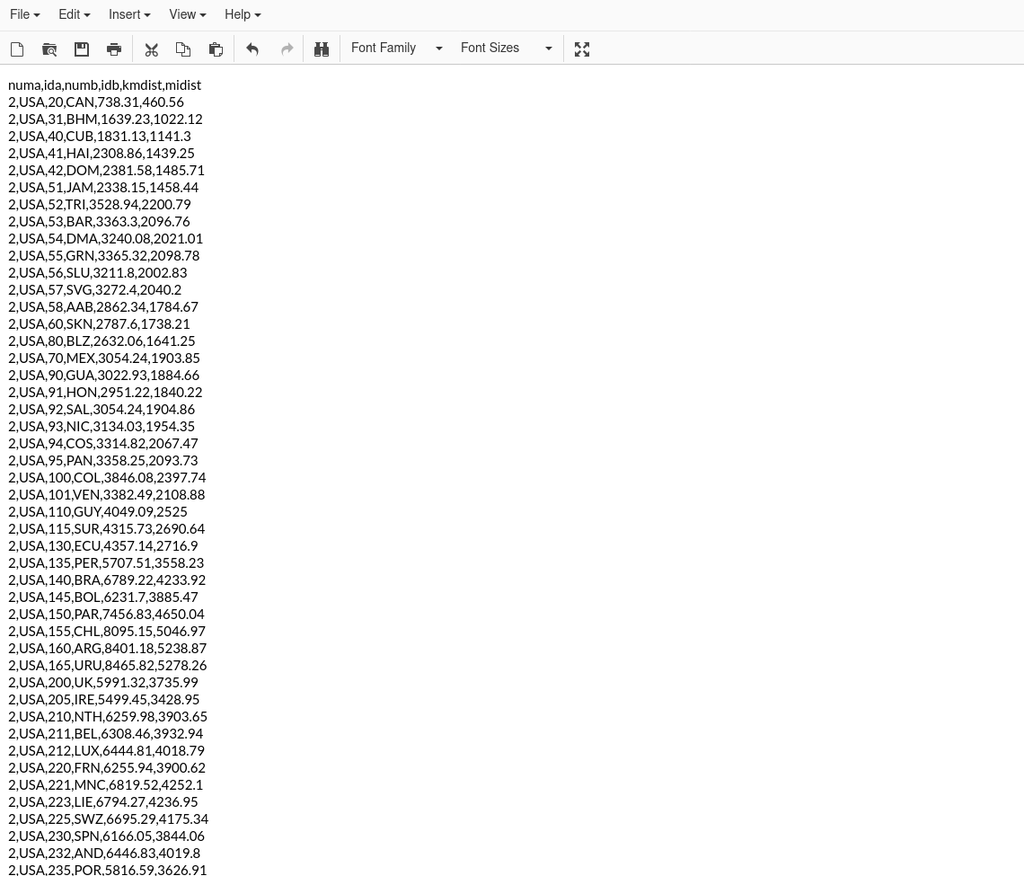

- some are *binary* files that need to be interpreted by a program

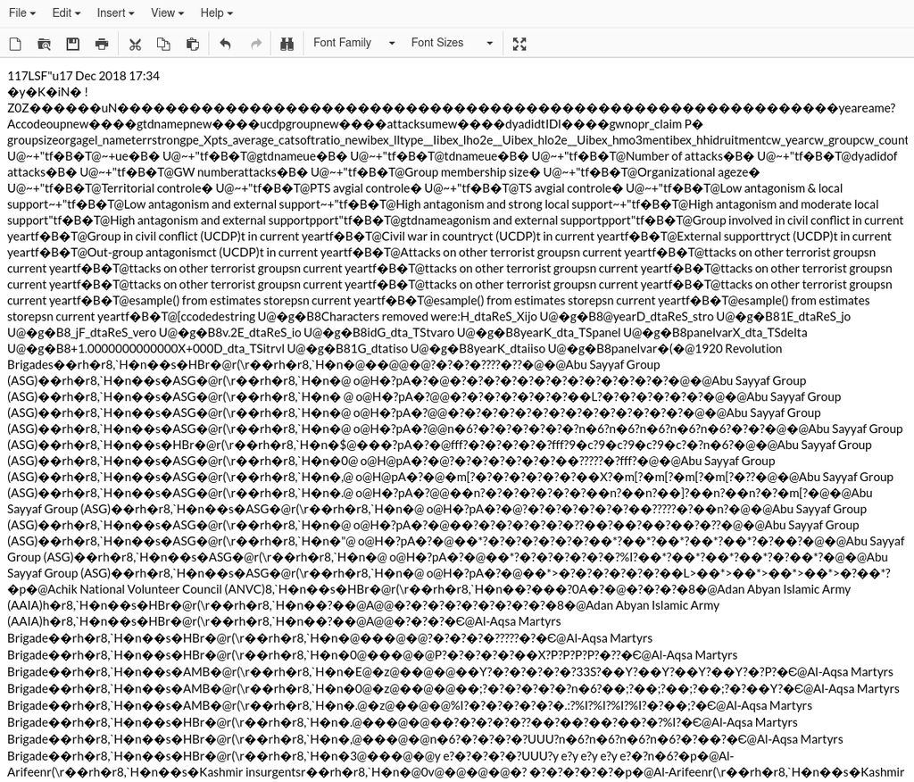

## Encoding

- Binary files contain some meta information on how they should be interpreted. Plain text files **do not**
- What specific bytes represent which character is defined in the *file encoding*
- Unfortunately, there are **different standards** (e.g., UTF-8, ASCII, Windows-1252)
- The file itself often gives no hint what encoding it uses 😿

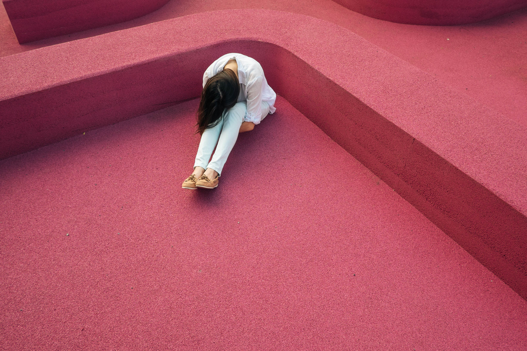

[Verne Ho](https://unsplash.com/@verneho) via unsplash.com

## Encoding: experiment

This file is encoded in UTF-8, which R expects:

```r
readLines("data/files/un-secretaries.txt")
```

```
[1] "Trygve Lie"              "Dag Hammarskjöld"
[3] "U Thant"                 "Kurt Waldheim"
[5] "Javier Perez de Cuellar" "Boutros Boutros-Ghali"
[7] "Kofi Annan"              "Ban Ki-Moon"
[9] "António Guterres"
```

Dag Hammarskjöld and António Guterres have names with letters that do not exist in the English alphabet and thus do not exist in the American Standard Code for Information Interchange (ASCII), one of the oldest encoding standards.

If we try to open the other file, where someone saved the same data, but with a different encoding:

```r
readLines("data/files/un-secretaries-ascii.txt")
```

```
[1] "Trygve Lie"              "Dag Hammarskj??ld"
[3] "U Thant"                 "Kurt Waldheim"
[5] "Javier Perez de Cuellar" "Boutros Boutros-Ghali"
[7] "Kofi Annan"              "Ban Ki-Moon"
[9] "Ant??nio Guterres"
```

## Encoding: pitfall

A common mishap is that people using Microsoft Windows use this program to open text files:

[figure not shown]

It has the very annoying habit of forcing a different encoding.

```r
file.copy("data/files/un-secretaries.txt", "data/files/un-secretaries_win.txt")
```

```
[1] FALSE
```

Let’s open this file with Notepad, do nothing and just save it (or open it in RStuido and use `File` -> `Save with Encoding`)

```r
readLines("data/files/un-secretaries_win.txt")
```

```
[1] "Trygve Lie"              "NA"
[3] "U Thant"                 "Kurt Waldheim"
[5] "Javier Perez de Cuellar" "Boutros Boutros-Ghali"
[7] "Kofi Annan"              "Ban Ki-Moon"
[9] "NA"
```

## Encoding: pitfall

You can sometimes return from something like that, but it’s almost never straightforward. We can guess the encoding based on some patterns in the text:

```r
readr::guess_encoding("data/files/un-secretaries_win.txt")
```

```
# A tibble: 1 × 2
  encoding confidence
  <chr>         <dbl>
1 ASCII             1
```

```r
# ISO-8859-1 is an alias for windows-1252
```

```r
readLines("data/files/un-secretaries_win.txt") |>
  stringi::stri_encode(from = "ISO-8859-1", to = "UTF-8")
```

```
[1] "Trygve Lie"              "NA"
[3] "U Thant"                 "Kurt Waldheim"
[5] "Javier Perez de Cuellar" "Boutros Boutros-Ghali"
[7] "Kofi Annan"              "Ban Ki-Moon"
[9] "NA"
```

```r
readr::read_csv(
  file = "data/files/un-secretaries_win.txt",
  locale = readr::locale(encoding = "ISO-8859-1")
)
```

```
# A tibble: 8 × 1
  `Trygve Lie`
  <chr>
1 <NA>
2 U Thant
3 Kurt Waldheim
4 Javier Perez de Cuellar
5 Boutros Boutros-Ghali
6 Kofi Annan
7 Ban Ki-Moon
8 <NA>
```

## File formats for tabular data: CSV

- Comma-Separated Values (CSV)
- plain text file
- data must be perfectly rectangular (each line must have the same number of cells)
- many functions to read (and write) CSV files: `read.csv`, `readr::read_csv`, `data.table::fread`

```r
readLines("data/files/csv-example.csv") |>
  head(15)
```

```
 [1] "numa,ida,numb,idb,kmdist,midist" "2,USA,20,CAN,738.31,460.56"
 [3] "2,USA,31,BHM,1639.23,1022.12"    "2,USA,40,CUB,1831.13,1141.3"
 [5] "2,USA,41,HAI,2308.86,1439.25"    "2,USA,42,DOM,2381.58,1485.71"
 [7] "2,USA,51,JAM,2338.15,1458.44"    "2,USA,52,TRI,3528.94,2200.79"
 [9] "2,USA,53,BAR,3363.3,2096.76"     "2,USA,54,DMA,3240.08,2021.01"
[11] "2,USA,55,GRN,3365.32,2098.78"    "2,USA,56,SLU,3211.8,2002.83"
[13] "2,USA,57,SVG,3272.4,2040.2"      "2,USA,58,AAB,2862.34,1784.67"
[15] "2,USA,60,SKN,2787.6,1738.21"
```

```r
rio::import("data/files/csv-example.csv")
```

```
    numa ida numb idb   kmdist   midist
1      2 USA   20 CAN   738.31   460.56
2      2 USA   31 BHM  1639.23  1022.12
3      2 USA   40 CUB  1831.13  1141.30
4      2 USA   41 HAI  2308.86  1439.25
5      2 USA   42 DOM  2381.58  1485.71
6      2 USA   51 JAM  2338.15  1458.44
7      2 USA   52 TRI  3528.94  2200.79
8      2 USA   53 BAR  3363.30  2096.76
9      2 USA   54 DMA  3240.08  2021.01
10     2 USA   55 GRN  3365.32  2098.78
11     2 USA   56 SLU  3211.80  2002.83
12     2 USA   57 SVG  3272.40  2040.20
13     2 USA   58 AAB  2862.34  1784.67
14     2 USA   60 SKN  2787.60  1738.21
```

[output cut: 188 more lines]

## File formats for tabular data: CSV

- like encoding: no single standard for CSV files
  - semicolon separators
  - comma in cells might be interpreted as separator
- downside ➖:
  - no meta-information about encoding, separators, quoting
- advantages ➕:
  - open format that is completely transparent
  - general compatibility with data processing and analysis tools
  - most commonly used file types for data storage (network effect)

```r
readLines("data/files/csv-example-semicolon.csv") |>
  head(15)
```

```
 [1] "numa;ida;numb;idb;kmdist;midist" "2;USA; 20;CAN;  738,31;  460,56"
 [3] "2;USA; 31;BHM; 1639,23; 1022,12" "2;USA; 40;CUB; 1831,13; 1141,30"
 [5] "2;USA; 41;HAI; 2308,86; 1439,25" "2;USA; 42;DOM; 2381,58; 1485,71"
 [7] "2;USA; 51;JAM; 2338,15; 1458,44" "2;USA; 52;TRI; 3528,94; 2200,79"
 [9] "2;USA; 53;BAR; 3363,30; 2096,76" "2;USA; 54;DMA; 3240,08; 2021,01"
[11] "2;USA; 55;GRN; 3365,32; 2098,78" "2;USA; 56;SLU; 3211,80; 2002,83"
[13] "2;USA; 57;SVG; 3272,40; 2040,20" "2;USA; 58;AAB; 2862,34; 1784,67"
[15] "2;USA; 60;SKN; 2787,60; 1738,21"
```

```r
readLines("data/files/csv-example-quotes.csv") |>
  head(15)
```

```
 [1] "numa,ida,numb,idb,kmdist,midist,capnamea"
 [2] "2,USA,20,CAN,738.31,460.56,\"Washington, DC\""
 [3] "2,USA,31,BHM,1639.23,1022.12,\"Washington, DC\""
 [4] "2,USA,40,CUB,1831.13,1141.3,\"Washington, DC\""
 [5] "2,USA,41,HAI,2308.86,1439.25,\"Washington, DC\""
 [6] "2,USA,42,DOM,2381.58,1485.71,\"Washington, DC\""
 [7] "2,USA,51,JAM,2338.15,1458.44,\"Washington, DC\""
 [8] "2,USA,52,TRI,3528.94,2200.79,\"Washington, DC\""
 [9] "2,USA,53,BAR,3363.3,2096.76,\"Washington, DC\""
[10] "2,USA,54,DMA,3240.08,2021.01,\"Washington, DC\""
[11] "2,USA,55,GRN,3365.32,2098.78,\"Washington, DC\""
[12] "2,USA,56,SLU,3211.8,2002.83,\"Washington, DC\""
[13] "2,USA,57,SVG,3272.4,2040.2,\"Washington, DC\""
[14] "2,USA,58,AAB,2862.34,1784.67,\"Washington, DC\""
[15] "2,USA,60,SKN,2787.6,1738.21,\"Washington, DC\""
```

## File formats for tabular data: Excel

```r
rio::import("data/files/unsc-membership.xls", sheet = "data")
```

```
      aclpcode                        aclpname code year unsc
1            1                         Algeria  DZA 1951    .
2            2                          Angola  AGO 1951    .
3            3                           Benin  BEN 1951    .
4            4                        Botswana  BWA 1951    .
5            5                    Burkina Faso  BFA 1951    .
6            6                         Burundi  BDI 1951    .
7            7                        Cameroon  CMR 1951    .
8            8                      Cape Verde  CPV 1951    .
9            9        Central African Republic  CAF 1951    .
10          10                            Chad  TCD 1951    .
11          11                         Comoros  COM 1951    .
12          12                           Congo  COG 1951    .
13          13                        Djibouti  DJI 1951    .
14          14                Egypt, Arab Rep.  EGY 1951    0
```

[output cut: 13303 more lines]

## File formats for tabular data: Stata & SPSS

- .dta are used by Stata
- .sav are used by SPSS
- You encounter them when someone in your team works with these programs
- Fortunately, the `haven` package has no issue dealing with them and `rio` provides a nice consistent interface
- When you look at the objects with `View()`, you even get the labels from Stata/SPSS under the column names (you can also use `labelled::var_label(stata_dat$orgage)` or `attributes(stata_dat$orgage)`)
- advantages ➕:
  - you can work with your team
- downside ➖:
  - not really used by any other programs
  - not particularly well suited for data storage

```r
stata_dat <- rio::import("data/files/terrorism-targets.dta")
rio::export(stata_dat, "data/files/terrorism-targets2.dta")
stata_dat
```

```
    year ccode
1   2004   645
2   1995   840
3   1996   840
4   1997   840
5   1998   840
6   1999   840
7   2000   840
8   2001   840
9   2002   840
10  2003   840
11  2004   840
12  2005   840
13  2006   840
14  2007   840
```

[output cut: 4395 more lines]

```r
spss_dat <- rio::import("data/files/journalism.sav")
rio::export(spss_dat, "data/files/journalism2.sav")
spss_dat
```

```
   COUNTRY       C9      C10      C11 AUTONOMY     C12A     C12B     C12C
1        1 3.738983 3.738983 4.214286 3.738983 4.310580 4.573379 3.941781
2        2 3.939058 4.019337 3.182336 3.979282 3.422096 4.475000 4.078212
3        3 3.940100 4.046512 3.530680 3.994186 4.071429 4.621667 3.470882
4        4 3.909988 4.203956 3.425373 4.055828 4.408867 4.634449 4.437346
5        5 3.774194 3.861272 2.768997 3.815186 3.311475 4.131498 4.136778
6        6 3.756803 3.923599 3.714530 3.841525 4.337884 4.594915 3.847079
7        7 3.712644 3.318182 3.393258 3.511364 3.930233 4.157303 4.044944
8        8 3.664865 3.756757 4.204301 3.709677 3.863095 4.801075 4.548387
9        9 3.509383 3.589333 3.142466 3.550667 4.125000 4.566489 3.848404
10      10 4.155894 4.281369 3.958175 4.218631 4.460076 4.847909 4.399240
11      12 4.014286 4.138329 3.240356 4.078571 4.119883 4.820513 4.103746
12      13 3.739669 3.771134 3.341772 3.754639 3.521834 4.514706 4.398305
13      14 2.980061 3.203077 2.743472 3.090491 3.698587 4.102804 3.842188
14      15 4.225455 4.141818 3.569369 4.184783 3.189591 4.663620 4.558011
```

[output cut: 1277 more lines]

## RData & RDS

- `R`’s own file formats
- R Data:
  - .RData or .rda extensions
  - can contain several objects *with their names* 😳
- “serialized” RData:
  - .rds file extension
  - contains one object without a name
- advantages ➕:
  - extremely flexible
  - pretty fast and/or efficient way to store data
- downside ➖:
  - not really used by any other programs

```r
load("data/files/leaders-twitter.Rdata")
save("elites.data", file = "data/files/leaders-twitter2.Rdata")
str(elites.data, give.head = T)
```

```
List of 6
 $ US     :'data.frame':    666 obs. of  23 variables:
  ..$ merge          : chr [1:666] "adl_initiative" "alangrayson" "alannunnelee" "alfranken" ...
  ..$ id             : int [1:666] 31455249 41017380 35663608 7334402 17220934 237403203 20209807 30912937 38401099 19677673 ...
  ..$ screen_name    : chr [1:666] "ADL_Initiative" "AlanGrayson" "AlanNunnelee" "alfranken" ...
  ..$ verified       : logi [1:666] FALSE FALSE FALSE TRUE TRUE TRUE ...
  ..$ url            : chr [1:666] "http://www.ADLnet.gov" "http://graysonforcongress.com" "http://senatornunnelee.com" "http://www.alfranken.com/" ...
  ..$ created_at     : chr [1:666] "Wed Apr 15 17:01:11 +0000 2009" "Tue May 19 01:00:40 +0000 2009" "Mon Apr 27 03:55:12 +0000 2009" "Sun Jul 08 21:48:38 +0000 2007" ...
  ..$ name           : chr [1:666] "ADL Initiative" "Alan Grayson" "Alan Nunnelee" "Al Franken" ...
  ..$ followers_count: int [1:666] 1281 32086 210 100863 2536631 98740 4774 2564 4239 10657 ...
  ..$ location       : chr [1:666] "Alexandria, VA, USA" "Orlando, FL" "Tupelo, MS" "Minnesota" ...
  ..$ description    : chr [1:666] "Advanced Distributed Learning Initiative" "" "Senator, State of Mississippi" "Official TeamFranken Twitter feed" ...
  ..$ time_zone      : chr [1:666] "Eastern Time (US & Canada)" "Eastern Time (US & Canada)" "Central Time (US & Canada)" "Central Time (US & Canada)" ...
  ..$ listed_count   : int [1:666] 119 1988 16 5176 36583 2427 521 145 265 518 ...
  ..$ lang           : chr [1:666] "en" "en" "en" "en" ...
  ..$ friends_count  : int [1:666] 207 6 1 20992 9 52 112 596 393 790 ...
  ..$ statuses_count : int [1:666] 2291 481 1 1132 695 701 386 696 2261 47 ...
  ..$ dw.nom.1       : num [1:666] NA -0.384 0.464 -0.472 NA 0.467 0.367 NA NA -0.275 ...
  ..$ icpsr.id       : int [1:666] NA 20908 21147 40904 NA 21119 20111 NA NA 20302 ...
  ..$ nameid         : chr [1:666] NA "G000556" "N000186" NA ...
  ..$ title          : chr [1:666] "Others" "House" "House" "Senate" ...
  ..$ party          : chr [1:666] "Nonpartisan" "D" "R" "D" ...
  ..$ state          : chr [1:666] NA NA "MS" NA ...
  ..$ gender         : chr [1:666] NA NA "M" NA ...
  ..$ idealPoint     : num [1:666] NA NA 0.829 NA NA ...
 $ UK     :'data.frame':    362 obs. of  4 variables:
  ..$ id             : int [1:362] 16884084 14561015 14758838 19858924 15157283 66774405 60738400 101712079 36664451 55253731 ...
  ..$ screen_name    : chr [1:362] "BrandonLewis" "damian57" "DamianCollins" "Michael_Ellis1" ...
  ..$ followers_count: int [1:362] 3300 2319 3780 1280 5143 3274 2302 2062 2599 3332 ...
  ..$ party          : chr [1:362] "conservatives" "conservatives" "conservatives" "conservatives" ...
 $ spain  :'data.frame':    298 obs. of  4 variables:
  ..$ id             : int [1:298] 343447873 16084460 21361705 304287573 18238467 301388743 20509689 50982086 249122306 76914701 ...
  ..$ screen_name    : chr [1:298] "marianorajoy" "patxilopez" "JoseantonioJun" "_Rubalcaba_" ...
  ..$ followers_count: int [1:298] 354256 152766 136280 136196 109201 92172 75649 73222 65644 64707 ...
  ..$ party          : chr [1:298] "pp" "psoe" "psoe" "psoe" ...
 $ NL     :'data.frame':    189 obs. of  4 variables:
  ..$ id             : int [1:189] 232306249 232296344 232294322 232283885 232297519 232305704 232292382 232307064 250842297 250519781 ...
  ..$ screen_name    : chr [1:189] "50PlusZeeland" "50PlusUtrecht" "50PlusO_IJssel" "50PlusFriesland" ...
  ..$ followers_count: int [1:189] 107 78 81 122 100 408 86 136 14 28 ...
  ..$ party          : chr [1:189] "vijftigplus" "vijftigplus" "vijftigplus" "vijftigplus" ...
 $ germany:'data.frame':    765 obs. of  4 variables:
  ..$ id             : int [1:765] 446558723 742830624 866494242 1375039512 1347962725 1448790385 1370417857 1269042739 1414088353 1339144020 ...
  ..$ screen_name    : chr [1:765] "_kraftsebastian" "Achim_Reinhardt" "ACichowicz" "AfD_Bayern" ...
  ..$ followers_count: int [1:765] 582 563 1765 452 357 103 114 629 272 373 ...
  ..$ party          : chr [1:765] "journalisten" "journalisten" "journalisten" "AFD" ...
 $ italy  :'data.frame':    215 obs. of  4 variables:
  ..$ id             : int [1:215] 399720804 16562213 540895773 228010525 460264679 426708964 45937235 376218450 372344749 149060372 ...
  ..$ screen_name    : chr [1:215] "_alessiovinci" "_arianna" "ale_moretti" "AlemannoTW" ...
  ..$ followers_count: int [1:215] 9934 19185 9936 32479 34877 429782 26935 37278 37916 73324 ...
  ..$ party          : chr [1:215] "" "" "PD" "PDL" ...
```

```r
saveRDS(elites.data, file = "data/files/leaders-twitter.rds")
elites_twitter <- readRDS("data/files/leaders-twitter.rds")
```

## JSON

- JavaScript Object Notation (JSON)
- plain text file
- two standards to save the same .json file type
  - JSON Lines: one record per line, like a csv (use `jsonlite::stream_in()`)
  - JSON: all records in one JSON string (use `jsonlite::fromJSON(`)
- advantages ➕:
  - very flexible beyond tabular data
  - widely used on the internet
- downside ➖:
  - allows for mind bending complexity (as we’ve seen yesterday)

```r
json_file <- repurrrsive::gh_repos_json()
gh_repos <- jsonlite::fromJSON(json_file, simplifyDataFrame = FALSE)
gh_repos |>
  lobstr::tree(max_length = 20)
```

```
<list>
├─<list>
│ ├─<list>
│ │ ├─id: 61160198
│ │ ├─name: "after"
│ │ ├─full_name: "gaborcsardi/after"
│ │ ├─owner: <list>
│ │ │ ├─login: "gaborcsardi"
│ │ │ ├─id: 660288
│ │ │ ├─avatar_url: "https://avatars.githubuserconten..."
│ │ │ ├─gravatar_id: ""
│ │ │ ├─url: "https://api.github.com/users/gab..."
│ │ │ ├─html_url: "https://github.com/gaborcsardi"
│ │ │ ├─followers_url: "https://api.github.com/users/gab..."
│ │ │ ├─following_url: "https://api.github.com/users/gab..."
│ │ │ ├─gists_url: "https://api.github.com/users/gab..."
│ │ │ ├─starred_url: "https://api.github.com/users/gab..."
│ │ │ ├─subscriptions_url: "https://api.github.com/users/gab..."
│ │ │ ├─organizations_url: "https://api.github.com/users/gab..."
│ │ │ ├─repos_url: "https://api.github.com/users/gab..."
...
```

```r
jsonlite::stream_out(elites.data$UK, file("data/elites_data_UK.json"))
```

```
Complete! Processed total of 362 rows.
```

```r
readLines("data/elites_data_UK.json") |>
  head() |>
  cat()
```

```
{"id":16884084,"screen_name":"BrandonLewis","followers_count":3300,"party":"conservatives"} {"id":14561015,"screen_name":"damian57","followers_count":2319,"party":"conservatives"} {"id":14758838,"screen_name":"DamianCollins","followers_count":3780,"party":"conservatives"} {"id":19858924,"screen_name…
```

## Exercises 1

1. Download the file from this address into the “data” folder and name it “internet_usage.xlsx” using R: https://api.worldbank.org/v2/en/indicator/IT.NET.USER.ZS?downloadformat=excel (hint: there are several R functions to download files, we’ve even seen one above)
2. Reproduce this plot (hint: you can get grey out cases with `gghighlight`):

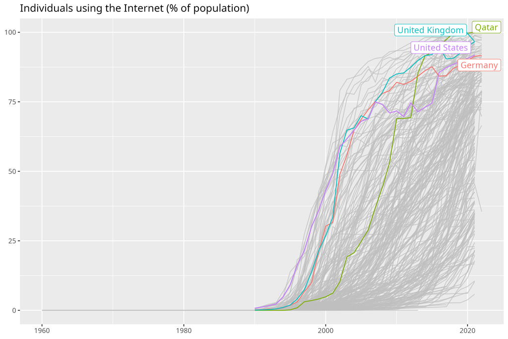

3. I created a terrible CSV file. Try to read it in anyway: “data/csv-bad-example.csv” (hint: since csvs are text files, you can look at them with any text editor)
4. Even when you manage to read in the file, the table still has issue. Explain what they are and how to correct them (hint: look at the data types of the columns)

# Transparent and efficient use of files

## Directory Structure

Weidmann (2023) suggest that your research project should have this directory structure:

- **raw/**
  - What lives here: raw data you collected yourself or that comes from other sources
  - What to do with the content: read only!
- **analysis/**
  - What lives here: cleaned/intermediate/analysis data and the analysis scripts that produced them
  - What does not live here: data that can’t be recreated from the raw data with the analysis scripts
  - What to do with the content: read input data and write intermediate data; produce analysis results
- **replication/**
  - What lives here: properly anonymized, cleaned data that is ready to be shared with others
  - What to do with the content: write-only (at the end of a project)

## Directory Structure

I find this structure more sensible:

- **data/**
  - What lives here: all raw data and intermediate data
  - What to do with the content: write data produced with an analysis script from a previous version of the data
- **analysis/**
  - What lives here: the RMD/Quarto files that clean, wrangle, and analyse the data
  - What does not live here: data
  - What to do with the content: execute the files to take a step in the data analysis pipeline
- **communication/**
  - What lives here: presentations and paper(s) communicating the results or status of your project
- **readme**: explains how everything belongs together

My preferred data structure:

```
my_awsome_paper
├── analysis
│   ├── 01._ingest-and-clean.qmd
│   ├── 02._annotation.qmd
│   └── 03._visualisationa-and-modelling.qmd
├── communication
│   ├── paper.qmd
│   └── slides.qmd
├── data
│   ├── 00._raw.csv
│   ├── 01._clean.rds
│   ├── 02._annotated.rds
│   └── 03._final.rds
└── readme.md

4 directories, 10 files
```

## Projects and relative paths

Specifically RStudio projects are a good way to organise your data, analysis scripts and academic output. This does not change your workflow dramatically, but makes your projects *portable* (and easier to back up). When working in a project, you can reference data by it’s relative position to the project’s main folder. This will mean that if the folder is copied to a different location, all your code will still run. The best example is the project we are in now.

This will work on your computer:

```r
plenary_speeches_raw <- rio::import("data/files/csv-example.csv")
```

This won’t, even though it works on my machine 😛:

```r
plenary_speeches_raw <- rio::import(
  "/home/johannes/Dropbox/Teaching/ess-web-scraping-data-management/03_Working_with_Files/data/files/csv-example.csv"
)
```

RStudio projects are not really necessary for this, especially given that Quarto sets the working directory of your documents to it’s source location by default. But the idea of keeping everything together can save you a lot of time otherwise spent on debugging issues (your own or these of others).

## File names

File names should be:

- machine-readable
- human-readable
- sort well
- start with a number (should lead with 0 if necessary)
- do not use capitalisation (file names are treated differently on Windows)
- no whitespace: use `_` to separate parts of the name (number, step, etc); use `-` to separate words (“ingest and clean”)

```
my_awsome_paper
├── analysis
│   ├── 01._ingest-and-clean.qmd
│   ├── 02._annotation.qmd
│   └── 03._visualisationa-and-modelling.qmd
├── communication
│   ├── paper.qmd
│   └── slides.qmd
├── data
│   ├── 00._raw.csv
│   ├── 01._clean.rds
│   ├── 02._annotated.rds
│   └── 03._final.rds
└── readme.md

4 directories, 10 files
```

## Make Files

For example, GNU Make is a tool which controls the generation of executables and other non-source files of a program from the program’s source files. It implements a paradigm that can be very useful in projects:

1. The make file contains the order in which results are built from the raw files: that is data and analysis scripts
2. When running the make command, make checks which files are up to date and which ones need (re-)building

Make files can help you keep track of your ongoing projects by making sure all files that depend on each other are up to data. You can check out the [{targets} R package](https://books.ropensci.org/targets/), which implements some advanced control over your projects and some nice visualisations. But the basic idea is simple:

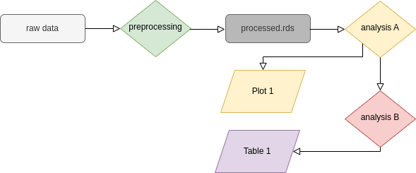

## Make Files

Say you found an issue in your pre-processing. You fix the issue and re-run the pre-processing script. But what else needs to be fixed? From the perspective of make, everything in the flowchart after the pre-processing step needs to be rebuilt. If you name your files in a sensible way and record the order of things, that should be no problem. You can use a little functions that implements make-like processing

```r
make_quarto <- function(files, destfiles = NULL, output_ext = ".html", ...) {
  if (is.null(destfiles)) {
    destfiles <- paste0(tools::file_path_sans_ext(files), output_ext)
  }

  # the oldest file should be the first source file, I record the first destfile, since it should be newer
  t <- file.info(destfiles[1])$ctime

  for (i in seq_along(files)) {
    if (
      # render file if source is newer than destination
      isTRUE(file.info(files[i])$ctime >= file.info(destfiles[i])$ctime) ||
        # or if output is NOT newer than previous destination file
        !isTRUE(file.info(destfiles[i])$ctime >= t)
    ) {
      cli::cli_progress_step("Making {destfiles[i]}.")
      quarto::quarto_render(
        input = files[i],
        output_file = destfiles[i]
      )
      cli::cli_progress_done()
    } else {
      cli::cli_inform(c("v" = "{destfiles[i]} already up to date."))
    }
    t <- file.info(destfiles[i])$ctime
  }
}
```

This is very barebones compared to the `targets` package, but I never really needed any of the other functions. Mostly I have been using the actual GNU make, but it’s syntax is quite different from other programs and it is not installed by default on Windows.

## Exercises 2

1. set up a directory for your research project and fill it with the mock data and analysis files you imagine you need
2. write a readme file that contains documentation of your file structure
3. Present it to the class tomorrow (for volunteers)

# Working with many files at the same time

## Reading multiple files

Let’s say your data is spread over several files:

```r
dataset_files <- list.files("data/files", pattern = ".csv$", full.names = TRUE)
dataset_files
```

```
[1] "data/files/csv-example-quotes.csv"
[2] "data/files/csv-example-semicolon.csv"
[3] "data/files/csv-example.csv"
```

You can read in one file without an issue:

```r
rio::import(dataset_files[1])
```

```
    numa ida numb idb   kmdist   midist       capnamea
1      2 USA   20 CAN   738.31   460.56 Washington, DC
2      2 USA   31 BHM  1639.23  1022.12 Washington, DC
3      2 USA   40 CUB  1831.13  1141.30 Washington, DC
4      2 USA   41 HAI  2308.86  1439.25 Washington, DC
5      2 USA   42 DOM  2381.58  1485.71 Washington, DC
6      2 USA   51 JAM  2338.15  1458.44 Washington, DC
7      2 USA   52 TRI  3528.94  2200.79 Washington, DC
8      2 USA   53 BAR  3363.30  2096.76 Washington, DC
9      2 USA   54 DMA  3240.08  2021.01 Washington, DC
10     2 USA   55 GRN  3365.32  2098.78 Washington, DC
11     2 USA   56 SLU  3211.80  2002.83 Washington, DC
12     2 USA   57 SVG  3272.40  2040.20 Washington, DC
13     2 USA   58 AAB  2862.34  1784.67 Washington, DC
14     2 USA   60 SKN  2787.60  1738.21 Washington, DC
```

[output cut: 188 more lines]

But how do you read in several?

## Reading multiple files

1. Get file names in one vector

```r
dataset_files <- list.files("data/files", pattern = ".csv$", full.names = TRUE)
dataset_files
```

```
[1] "data/files/csv-example-quotes.csv"
[2] "data/files/csv-example-semicolon.csv"
[3] "data/files/csv-example.csv"
```

2. Define reading function

```r
read_dat <- function(x) {
  rio::import(x)
}
```

3. Loop over files

```r
dataset_list <- map(dataset_files, read_dat)
```

4. Bind into one table

```r
bind_rows(dataset_list)
```

```
Error in `bind_rows()`:
! Can't combine `..1$kmdist` <double> and `..2$kmdist` <character>.
```

-> change the `read_dat` function until all data frames are the same

```r
read_dat <- function(x) {
  rio::import(x) |>
    mutate(
      kmdist = str_replace(kmdist, ",", "."),
      midist = str_replace(midist, ",", ".")
    ) |>
    mutate(kmdist = as.numeric(kmdist), midist = as.numeric(midist))
}
map(dataset_files, read_dat) |>
  bind_rows()
```

```
    numa ida numb idb   kmdist   midist       capnamea
1      2 USA   20 CAN   738.31   460.56 Washington, DC
2      2 USA   31 BHM  1639.23  1022.12 Washington, DC
3      2 USA   40 CUB  1831.13  1141.30 Washington, DC
4      2 USA   41 HAI  2308.86  1439.25 Washington, DC
5      2 USA   42 DOM  2381.58  1485.71 Washington, DC
6      2 USA   51 JAM  2338.15  1458.44 Washington, DC
7      2 USA   52 TRI  3528.94  2200.79 Washington, DC
8      2 USA   53 BAR  3363.30  2096.76 Washington, DC
9      2 USA   54 DMA  3240.08  2021.01 Washington, DC
10     2 USA   55 GRN  3365.32  2098.78 Washington, DC
11     2 USA   56 SLU  3211.80  2002.83 Washington, DC
12     2 USA   57 SVG  3272.40  2040.20 Washington, DC
13     2 USA   58 AAB  2862.34  1784.67 Washington, DC
14     2 USA   60 SKN  2787.60  1738.21 Washington, DC
```

[output cut: 592 more lines]

## Files as databases: Why?

- when working with larger datasets, the available memory of your computer becomes an issue
- “big data” is often defined as datasets larger than your memory
- in these cases you have four choices
1. Let each Quarto file do less (and break up tasks into more files)
2. Chunk your analysis. Often, you can perform analysis or pre-processing on one subset of the data after the other and combine the results
3. Get better hardware or use cloud computing (both are expensive, [but possible](https://cloudyr.github.io/packages/index.html))
4. **Do not load the full data into memory**

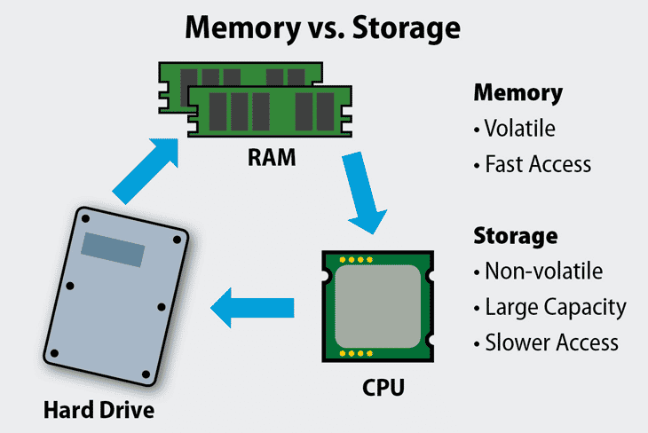

## Files as databases: How?

```r
corp_hoc <- "data/Corp_HouseOfCommons_V2.rds"
if (!file.exists(corp_hoc)) {
  library(dataverse)
  Sys.setenv("DATAVERSE_SERVER" = "dataverse.harvard.edu")
  # get dataset by doi
  ds <- get_dataset("doi:10.7910/DVN/L4OAKN")
  # you can inspect that object with
  # as_tibble(ds[["files"]][, c("label", "id")])

  url <- get_file(
    3758859L,
    dataset = "doi:10.7910/DVN/ZY3RV7",
    return_url = TRUE
  )

  curl::curl_download(url, destfile = corp_hoc, quiet = FALSE)
}
corp_hoc_df <- readRDS(corp_hoc) |>
  mutate(date = as.Date(date))
```

Let’s say this was not stored as one file, but a collection of CSV files:

```r
if (!dir.exists("data/house_of_commons")) {
  # I split this into file just for demonstration purposes
  corp_hoc_list <- split(corp_hoc_df, corp_hoc_df$party)
  dir.create("data/house_of_commons")
  for (party in names(corp_hoc_list)) {
    rio::export(
      corp_hoc_list[[party]],
      paste0("data/house_of_commons/", party, ".csv")
    )
  }
}
list.files("data/house_of_commons")
```

```
 [1] "APNI.csv"                      "Birkenhead Social Justice.csv"
 [3] "Change UK.csv"                 "Con.csv"
 [5] "DUP.csv"                       "GPEW.csv"
 [7] "Independent.csv"               "Lab.csv"
 [9] "LibDem.csv"                    "other.csv"
[11] "PlaidCymru.csv"                "Referendum.csv"
[13] "Respect.csv"                   "SDLP.csv"
[15] "SDP.csv"                       "SNP.csv"
[17] "The Independents.csv"          "UKIP.csv"
[19] "UKUP.csv"                      "UPUP.csv"
[21] "UUP.csv"
```

## Files as databases: How?

We could read all of them in and combine them, like above. Or we can use `arrow` to treat them as a database:

```r
library(arrow)
corp_hoc_con <- open_dataset(sources = "data/house_of_commons", format = "csv")
```

The `corp_hoc_con` is way smaller than the actual data object:

```r
object.size(corp_hoc_con)
```

```
504 bytes
```

```r
object.size(corp_hoc_df) |>
  format(units = "MB")
```

```
[1] "2269.5 Mb"
```

Yet we can still treat it like a normal data.frame:

```r
corp_hoc_con |>
  mutate(date = as.Date(date)) |>
  filter(date >= "2000-01-01", date < "2001-01-01") |>
  select(party) |>
  collect() |> # special function when working with DBs
  count(party, sort = TRUE)
```

```
# A tibble: 11 × 2
   party           n
   <chr>       <int>
 1 Lab         31786
 2 Con         21703
 3 LibDem       5370
 4 UUP           842
 5 PlaidCymru    373
 6 other         140
 7 SNP           119
 8 Independent    85
 9 DUP            67
10 SDLP           64
11 UKUP           56
```

The only difference is that we have to call collect at some point, to load the data into memory. Since we can filter it though, the memory footprint will still be much smaller.

## Exercises 3

1. When might it make sense to treat a folder full of files as a database?
2. When could it make sense to save data in an arrow database full of csv files?
3. `arrow` also supports a file format called Parquet. Using it instead of CSV files increases speed and reduces file sizes, while it is also widely used by other languages and programs. Create a new folder where you store the Houses of Commons data in one file per speaker (hint read `?arrow::write_parquet` first).
4. Connect to the “database” of Parquet files and make a plot showing how many entries there are over the years per party.

# Collaborative working

## Git

- git was developed for collaborative work on software
- it is excellently suited for research projects as well!
- you can get a free Github premium account with a university address
- this enables you to have private repositories (otherwise all repositories are public)
- widely used system with good learning materials, for example: Bryan et al. (2017)

-> GitHub is for code though, not data!

## Git some Version Control

Git is an extensive application and too much to go through. But you do not need all the functionality to make efficient use of it’s main promise: keeping track of what is happening in your projects and giving you the ability to revert to an older state of your project.

[figure not shown]

This screenshot shows the last months of my PhD, when I was furiously working on integrating comments from different people. Not only helped git to show me my progress nicely, I also did not have to worry about accidentally deleting anything that might still prove valuable. Especially towards the end, I often removed sections or copied them to other chapters. Whenever I could not find a specific section, I went back to the last commit when I could still remember where it was.

Additionally, GitHub offers some nice features to organise and plan projects around *issues*.

[figure not shown]

Here you can note down remaining problems and keep track of your progress. It keeps your head free for other things!

Learn more, e.g., at: https://happygitwithr.com/

## Google Sheets

Google sheets is a free service by Google–which can be controlled from R!

```r
library(googlesheets4)
# write
write_sheet(gss_cat, "gs4-test")
# read
cats_df <- read_sheet(
  "https://docs.google.com/spreadsheets/d/1XdqfPXrZCTim156m8SteKG_teOgj9AJLcAHOMrV_wfI/edit?usp=sharing"
)
# update
cats_df_updated <- cats_df |>
  add_case(
    year = 2000,
    marital = "Never married",
    age = 26,
    race = "White",
    rincome = "$8000 to 9999",
    partyid = "Ind,near rep",
    relig = "Protestant",
    denom = "Southern baptist",
    tvhours = 12
  )
write_sheet(
  cats_df_updated,
  ss = "https://docs.google.com/spreadsheets/d/1XdqfPXrZCTim156m8SteKG_teOgj9AJLcAHOMrV_wfI/edit?usp=sharing",
  sheet = "gss_cat_updated"
)
```

## Data storage alternatives

1. Whatever your university provides
2. Dropbox, OneDrive, Box, etc
3. Self hosted services like Nextcloud, Owncloud, etc.

Pitfalls:

- always back up your data (3-2-1 backup strategy)!
- think about who you give access
- make sure to not work on the same file at the same time as someone else

## Exercises 4

1. If you have a Google account, try to upload and download some data to Google Sheets

# Wrap Up

# References

Bryan, Jenny, STAT 545 TAs, and Jim Hester. 2017. *Happy Git and GitHub for the useR*. 1st ed. https://happygitwithr.com/.

Weidmann, Nils B. 2023. *Data Management for Social Scientists: From Files to Databases*. 1st ed. Cambridge University Press. https://doi.org/10.1017/9781108990424.